# SVM

Дмитрий Корчемкин, Владимир Агеев, 622гр.

```r
library(e1071)
library(kernlab)
library(LiblineaR)
library(psych)
library(ISLR)
library(gmum.r)
library(penalizedSVM)
library(ade4)
library(MASS)
library(glmnet)
```

# Линейно разделимые данные

Сгенерируем данные, которые линейно разделимы

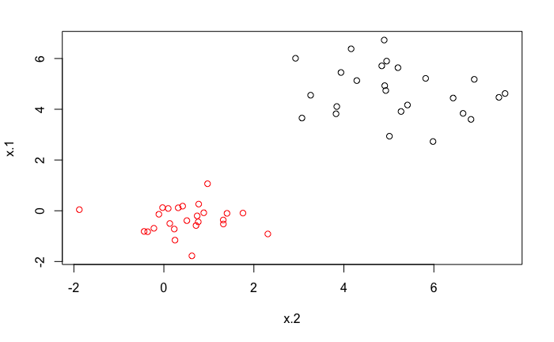

```r
set.seed(100)
x <- matrix(c(rnorm(50), rnorm(50,5)), ncol = 2, nrow = 50, byrow = TRUE)
y <- c(rep(1, 25), rep(2,25))
simple.dat <- data.frame(x = x, y = as.factor(y))
plot(simple.dat[,c(2,1)], col = c("red", "black")[y])
```

Построим svm с линейным ядром, данные нормировать не будем, штраф пусть будет “произвольным”

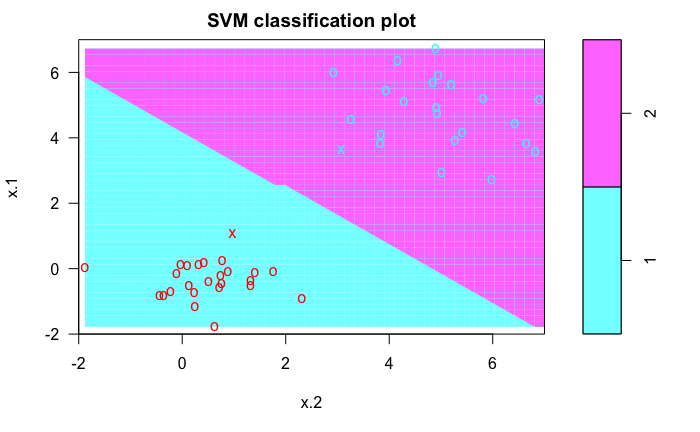

```r
svm.linearfit <- svm(y ~., data = simple.dat, kernel = "linear", cost = 10)
plot(svm.linearfit, simple.dat, symbolPalette = rainbow(2), xlim = c(-2, 7), ylim = c(-2, 7))
```

На графике крестиками отмечаются опорные вектора. Их можно получить из объекта, который возвращает svm() по имени $index.

```r
svm.linearfit$index
```

```
[1] 20 42
```

Сгенерируем тестовую выборку и проверим качество классификации.

```r
x.test <- matrix(c(rnorm(50), rnorm(50,5)), ncol = 2, nrow = 50, byrow = TRUE)
y.test <- c(rep(1, 25), rep(2,25))
svm.pred <- predict(svm.linearfit, newdata = x.test)
```

Confusion matrix:

```r
tb <- table(svm.pred, y.test)
print(tb)
```

```
        y.test
svm.pred  1  2
       1 25  0
       2  0 25
```

Average classification accuracy:

```r
mean(diag(prop.table(tb, 1)))
```

```
[1] 1
```

В следующем разделе подробнее разберем какие параметры есть у svm() и попробуем классифицировать более сложные данные.

# Про пакет e1071

Для построения svm будем использовать пакет e1071 и функцию svm() оттуда. Функция имеет следующие параметры:

- formula – a symbolic description of the model to be fit
- data – data frame (optional)
- x – a data matrix, a vector, or a sparse matrix
- y – a response vector with one label for each row/component of x. Can be either a factor (for classification tasks) or a numeric vector (for regression).
- scale – A logical vector indicating the variables to be scaled. Per default, data are scaled internally (both x and y variables) to zero mean and unit variance. The center and scale values are returned and used for later predictions.
- type – тип svm. Регрессия / классификация + различные формы задачи квадратичного программирования. По умолчанию для классификации используется тип C-classification, где задача сформулирована в следующей форме:
  $$\begin{align*}
  \begin{cases}
  \mathbf{e}^\mathrm{T}\mathbf{\alpha} - \frac{1}{2}\mathbf{\alpha}^\mathrm{T}Q\mathbf{\alpha}\rightarrow \max\limits_{\mathbf{\alpha}}, & Q_{ij} = y_iy_j K(\mathbf{x}_i, \mathbf{x}_j) = y_iy_j\phi(\mathbf{x}_i)^\mathrm{T}\phi(\mathbf{x}_j)\\
  \mathbf{y}^\mathrm{T}\mathbf{\alpha} = 0, \\
  0 \leq \alpha_i \leq C, & i = 1,\ldots, n.
  \end{cases}
  \end{align*}$$
  Такая задача эквивалентна задаче минимизации и регуляризации эмпирического риска
  $$\begin{align*}
  \sum\limits_{i = 1}^{p}\left(1 - M_i(\beta, \beta_0)\right)_{+} + \frac{1}{2C}\|\beta\|_2^2 \rightarrow \min\limits_{\beta, \beta_0}.
  \end{align*}$$

  (Здесь 1/(2С) оказыватся эквивалентной обозначению $\eta$ в слайдах). Отсюда интерпретация, что чем больше C, тем слабее регуляризация (меньше опорных векторов, уже граница), чем меньше – тем сильнее регуляризация, больше опорных векторов, шире граница; больше векторов, которым разрешается оказаться по другую сторону границы, но не в другом классе (опорные-нарушители у Воронцова).
- kernel – Ядро. Поддерживаются следующие ядра:
- - linear:
    $$\mathbf{u}^\mathrm{T}\mathbf{v},$$
- - polynomial:
    $$(\gamma \mathbf{u}^\mathrm{T}\mathbf{v} + c_0)^d,$$
- - radial basis:
    $$e^{-\gamma |u - v|^2}$$
- - sigmoid:
    $$\tanh(\gamma \mathbf{u}^\mathrm{T} \mathbf{v} + c_0)$$
- degree – параметр полиномиального ядра (default: 3)
- gamma – необходимый паратетр для всех ядер кроме линейного (default: 1/(data dimension))
- coef0 – прарметр полиномиального и сигмоидного ядра (default: 0)
- cost – цена нарушения ограничений (default: 1). Это константа C в формулировке задачи. Чем болше С – тем больше штраф,тем уже граница.
- nu – параметр для $\nu$-формулировки задачи
- class.weights – вектор весов групп (default: 1)
- cachesize – кэш в Мб (default: 40)
- tolerance – условие остановки (default: 0.001)
- epsilon – epsilon in the insensitive-loss function (default: 0.1)
- shrinking – option whether to use the shrinking-heuristics (default: TRUE)
- cross – если больше 0, то производится k-fold cross validation
- fitted – включать ли оценки в модель (default: TRUE)
- probability – разрешать ли предсказания по вероятности
- … – дополнительные параметры для svm.default
- subset – вектор индексов тренировочной выборки
- na.action – функция, определяющая, что делать с NA.

# Линейно неразделимые данные

Данные – Orange Juice Data

Данные содержат 1070 покупок апельсинового сока. Покупатели выбирали либо Citrus Hill, либо Minute Maid. Всего 18 признаков:

- Purchase – фактор, означающий, какая марка сока была куплена
- WeekofPurchase – неделя покупки (сколько продано за неделю)
- Store ID – Store ID
- PriceCH – цена сока CH
- PriceMM – цена сока MM
- DiscCH – скидка на сок CH
- DiscMM – скидка на сок MM
- SpecialCH – факторный признак, было ли специальное предложение на сок
- SpecialMM – факторный признак, было ли специальное предложение на сок
- LoyalCH – лояльность покупателя бренду CH
- SalePriceMM – цена продажи сока MM (магазином)
- SalePriceCH – цена продажи сока CH (магазином)
- PriceDiff – розничная цена MM - розничная цена CH
- Store7 – фактор, произошла ли покупка в магазине Store 7
- PctDiscMM – процент скидки на MM
- PctDiscСH – процент скидки на CH
- ListPriceDiff – List price of MM - list price of CH
- STORE – в каком из пяти магазинов произошла покупка

```r
dat <- OJ
str(dat)
```

```
'data.frame':   1070 obs. of  18 variables:
 $ Purchase      : Factor w/ 2 levels "CH","MM": 1 1 1 2 1 1 1 1 1 1 ...
 $ WeekofPurchase: num  237 239 245 227 228 230 232 234 235 238 ...
 $ StoreID       : num  1 1 1 1 7 7 7 7 7 7 ...
 $ PriceCH       : num  1.75 1.75 1.86 1.69 1.69 1.69 1.69 1.75 1.75 1.75 ...
 $ PriceMM       : num  1.99 1.99 2.09 1.69 1.69 1.99 1.99 1.99 1.99 1.99 ...
 $ DiscCH        : num  0 0 0.17 0 0 0 0 0 0 0 ...
 $ DiscMM        : num  0 0.3 0 0 0 0 0.4 0.4 0.4 0.4 ...
 $ SpecialCH     : num  0 0 0 0 0 0 1 1 0 0 ...
 $ SpecialMM     : num  0 1 0 0 0 1 1 0 0 0 ...
 $ LoyalCH       : num  0.5 0.6 0.68 0.4 0.957 ...
 $ SalePriceMM   : num  1.99 1.69 2.09 1.69 1.69 1.99 1.59 1.59 1.59 1.59 ...
 $ SalePriceCH   : num  1.75 1.75 1.69 1.69 1.69 1.69 1.69 1.75 1.75 1.75 ...
 $ PriceDiff     : num  0.24 -0.06 0.4 0 0 0.3 -0.1 -0.16 -0.16 -0.16 ...
 $ Store7        : Factor w/ 2 levels "No","Yes": 1 1 1 1 2 2 2 2 2 2 ...
 $ PctDiscMM     : num  0 0.151 0 0 0 ...
 $ PctDiscCH     : num  0 0 0.0914 0 0 ...
 $ ListPriceDiff : num  0.24 0.24 0.23 0 0 0.3 0.3 0.24 0.24 0.24 ...
 $ STORE         : num  1 1 1 1 0 0 0 0 0 0 ...
```

Матриксплот без признаков вида ID магазина и коллинеарных признаков (например PctDiscMM коллинеарен DiscMM).

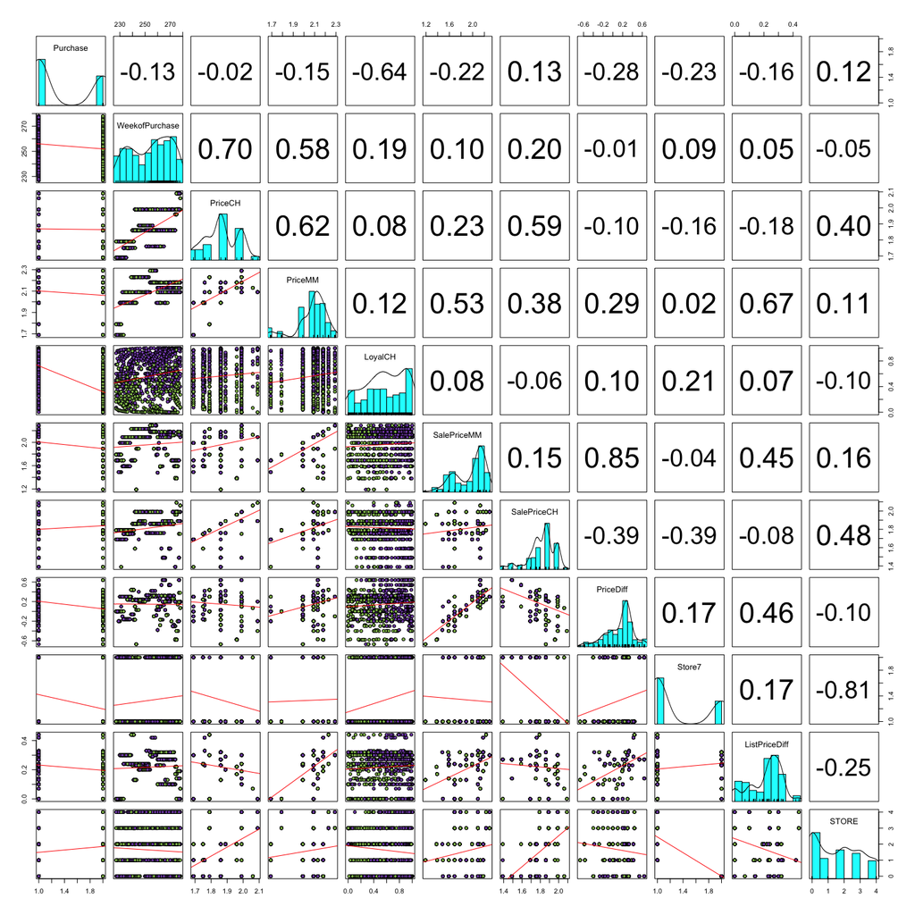

```r
factor.colors <- palette(c(rgb(134,82,187, maxColorValue=255),
    rgb(148,195,92, maxColorValue=255)))
pairs.panels(dat[,-c(3,6,7, 8, 9, 15, 16)],
               bg=factor.colors[dat$Purchase],
               pch=21,
               lm=TRUE,
               lwd = 1,
               ellipses = FALSE)
```

Есть подозрения, что лояльности достаточно, чтобы хорошо поделить группы.

```r
set.seed(100)
train.idx <- sample(seq(from = 1, to = nrow(dat)), size = floor(0.7 * nrow(dat)))
train.df <- dat[train.idx,-c(3, 6, 7, 8,9,11,14,15,16,18)]
test.df <- dat[-train.idx,-c(3, 6, 7, 8,9,11,14,15,16,18)]
```

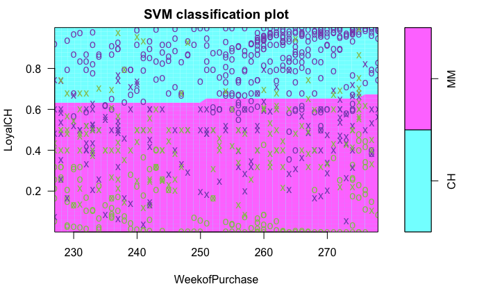

```r
svmfit <- svm(Purchase ~., data = train.df, kernel = "linear", cost = 100)
plot(svmfit, train.df,  LoyalCH ~ WeekofPurchase)
```

```r
summary(svmfit)
```

```
Call:
svm(formula = Purchase ~ ., data = train.df, kernel = "linear", cost = 100)


Parameters:
   SVM-Type:  C-classification
 SVM-Kernel:  linear
       cost:  100
      gamma:  0.1428571

Number of Support Vectors:  305

 ( 153 152 )


Number of Classes:  2

Levels:
 CH MM
```

Проверим на тестовой выборке.

```r
svm.pred <- predict(svmfit, newdata = test.df)
```

Confusion matrix:

```r
tb <- table(svm.pred, test.df$Purchase)
print(tb)
```

```
svm.pred  CH  MM
      CH 173  31
      MM  21  96
```

Average classification accuracy:

```r
mean(diag(prop.table(tb, 1)))
```

```
[1] 0.834276
```

## Сравнение с LDA

```r
oj.lda <- lda(Purchase ~., data = train.df, prior = c(0.5,0.5))
```

```
variables are collinear
```

```r
oj.lda
```

```
Call:
lda(Purchase ~ ., data = train.df, prior = c(0.5, 0.5))

Prior probabilities of groups:
 CH  MM
0.5 0.5

Group means:
   WeekofPurchase  PriceCH  PriceMM   LoyalCH SalePriceCH  PriceDiff ListPriceDiff
CH       256.2810 1.869281 2.104858 0.7155003    1.796275 0.21115468     0.2355773
MM       251.3931 1.861069 2.055483 0.3026867    1.835690 0.05475862     0.1944138

Coefficients of linear discriminants:
                        LD1
WeekofPurchase -0.001843242
PriceCH         0.137413129
PriceMM        -0.355315713
LoyalCH        -4.028136951
SalePriceCH     0.447112377
PriceDiff      -1.184704658
ListPriceDiff  -0.705960397
```

Проверим на тестовой выборке

```r
oj.lda.predict <- predict(oj.lda, test.df[,-1])$class
```

Confusion matrix:

```r
tb <- table(oj.lda.predict, test.df$Purchase)
print(tb)
```

```
oj.lda.predict  CH  MM
            CH 166  27
            MM  28 100
```

Average classification accuracy:

```r
mean(diag(prop.table(tb, 1)))
```

```
[1] 0.8206768
```

Результат чуть хуже SVM с линейным ядром и “произвольным” (никак не подбиравшимся) параметром C.

## Kernel-trick + CV

Подберем ядро и параметры кроссвалидацией с помощью функции tune().

Линейное ядро.

```r
set.seed(100)
tune.linear <- tune(svm, Purchase ~., data = train.df, kernel = "linear", ranges = list(cost = c(0.001, 0.01, 0.1, 1, 5, 10, 50, 100)), scale = TRUE)
summary(tune.linear)
```

```
Parameter tuning of ‘svm’:

- sampling method: 10-fold cross validation

- best parameters:
 cost
  0.1

- best performance: 0.1723243

- Detailed performance results:
   cost     error dispersion
1 1e-03 0.3859279 0.05875006
2 1e-02 0.1763243 0.04532209
3 1e-01 0.1723243 0.04010710
4 1e+00 0.1763423 0.04716930
5 5e+00 0.1750090 0.04488428
6 1e+01 0.1750090 0.04488428
7 5e+01 0.1750090 0.04488428
8 1e+02 0.1750090 0.04488428
```

```r
tune.linear$best.model
```

```
Call:
best.tune(method = svm, train.x = Purchase ~ ., data = train.df, ranges = list(cost = c(0.001, 0.01, 0.1, 1, 5, 10, 50, 100)), kernel = "linear",
    scale = TRUE)


Parameters:
   SVM-Type:  C-classification
 SVM-Kernel:  linear
       cost:  0.1
      gamma:  0.1428571

Number of Support Vectors:  326
```

Используем выбранную модель для предсказания классов на тестовой выборке.

```r
svm.linear.pred <- predict(tune.linear$best.model, newdata = test.df)
```

Confusion matrix:

```r
tb <- table(svm.linear.pred, test.df$Purchase)
print(tb)
```

```
svm.linear.pred  CH  MM
             CH 173  31
             MM  21  96
```

Average classification accuracy:

```r
mean(diag(prop.table(tb, 1)))
```

```
[1] 0.834276
```

Radial basis

```r
tune.radial <- tune(svm, Purchase ~., data = train.df, kernel = "radial", ranges = list(cost = c(0.01, 0.1, 1, 5, 10, 50), gamma = c(0.1,0.5, 1, 2, 3, 4)), scale = TRUE)
summary(tune.radial)
```

```
Parameter tuning of ‘svm’:

- sampling method: 10-fold cross validation

- best parameters:
 cost gamma
  0.1   0.5

- best performance: 0.1736216

- Detailed performance results:
    cost gamma     error dispersion
1   0.01   0.1 0.3871892 0.06031002
2   0.10   0.1 0.1803063 0.05446133
3   1.00   0.1 0.1749189 0.04603225
```

[output cut: 33 more lines]

```r
tune.radial$best.model
```

```
Call:
best.tune(method = svm, train.x = Purchase ~ ., data = train.df, ranges = list(cost = c(0.01, 0.1, 1, 5, 10, 50), gamma = c(0.1, 0.5, 1,
    2, 3, 4)), kernel = "radial", scale = TRUE)


Parameters:
   SVM-Type:  C-classification
 SVM-Kernel:  radial
       cost:  0.1
      gamma:  0.5

Number of Support Vectors:  548
```

```r
svm.radial.pred <- predict(tune.radial$best.model, newdata = test.df)
```

Confusion matrix:

```r
tb <- table(svm.radial.pred, test.df$Purchase)
print(tb)
```

```
svm.radial.pred  CH  MM
             CH 177  40
             MM  17  87
```

Average classification accuracy:

```r
mean(diag(prop.table(tb, 1)))
```

```
[1] 0.8261033
```

Sigmoid

```r
tune.sigmoid <- tune(svm, Purchase ~., data = train.df, kernel = "sigmoid", ranges = list(cost = c(0.01, 0.1, 1, 5, 10, 50), gamma = c(0.5, 1, 2, 3, 4)), scale = TRUE)
summary(tune.sigmoid)
```

```
Parameter tuning of ‘svm’:

- sampling method: 10-fold cross validation

- best parameters:
 cost gamma
 0.01   0.5

- best performance: 0.2135676

- Detailed performance results:
    cost gamma     error dispersion
1   0.01   0.5 0.2135676 0.06666277
2   0.10   0.5 0.2910450 0.06113631
3   1.00   0.5 0.3097297 0.06899147
```

[output cut: 27 more lines]

```r
tune.sigmoid$best.model
```

```
Call:
best.tune(method = svm, train.x = Purchase ~ ., data = train.df, ranges = list(cost = c(0.01, 0.1, 1, 5, 10, 50), gamma = c(0.5, 1, 2, 3,
    4)), kernel = "sigmoid", scale = TRUE)


Parameters:
   SVM-Type:  C-classification
 SVM-Kernel:  sigmoid
       cost:  0.01
      gamma:  0.5
     coef.0:  0

Number of Support Vectors:  565
```

```r
svm.sigmoid.pred <- predict(tune.sigmoid$best.model, newdata = test.df)
```

Confusion matrix:

```r
tb <- table(svm.sigmoid.pred, test.df$Purchase)
print(tb)
```

```
svm.sigmoid.pred  CH  MM
              CH 180  58
              MM  14  69
```

Average classification accuracy:

```r
mean(diag(prop.table(tb, 1)))
```

```
[1] 0.7938139
```

# Сравнение ядер на модельных данных

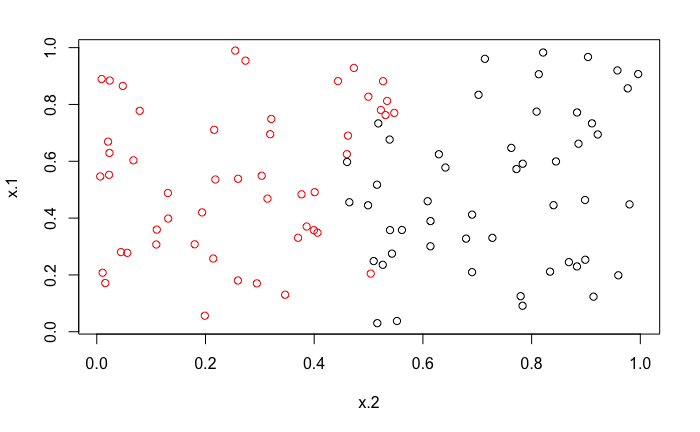

```r
set.seed(100)
x <- matrix(c(runif(100), runif(50,max = 0.55), runif(50,min = 0.45)), ncol = 2, nrow = 100)
y <- c(rep(1, 50), rep(2,50))
simple.dat <- data.frame(x = x, y = as.factor(y))
plot(simple.dat[,c(2,1)], col = c("red", "black")[y])
```

Линейное

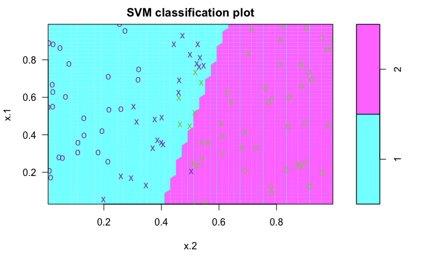

```r
set.seed(100)
tune.model.linear <- tune(svm, y ~ ., data = simple.dat, kernel = "linear", ranges = list(cost = c(0.001, 0.01, 0.1, 1, 5, 10, 50, 100)), scale = TRUE)
plot(tune.model.linear$best.model, simple.dat)
```

Тестовые данные

```r
set.seed(100)
x.test <- matrix(c(runif(100), runif(50,max = 0.55), runif(50,min = 0.45)), ncol = 2, nrow = 100)
y.test <- c(rep(1, 50), rep(2,50))
```

Average accuracy

```r
svm.model.pred <- predict(tune.model.linear$best.model, newdata = x.test)
tb <- table(svm.model.pred, y.test)
mean(diag(prop.table(tb, 1)))
```

```
[1] 0.9516259
```

RBF

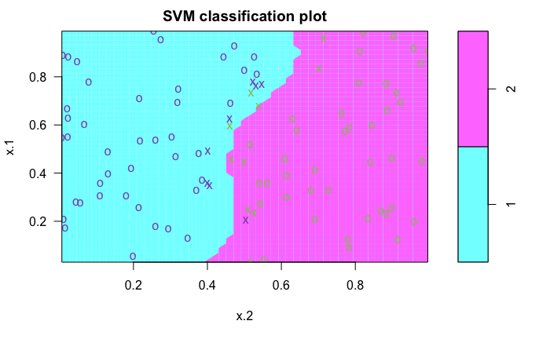

```r
set.seed(100)
tune.model.rbf <- tune(svm, y ~ ., data = simple.dat, kernel = "radial", ranges = list(cost = c(0.01, 0.1, 1, 5, 10, 50), gamma = c(0.1, 0.5, 1, 2, 3, 4)), scale = TRUE)
plot(tune.model.rbf$best.model, simple.dat)
```

Average accuracy

```r
svm.model.pred <- predict(tune.model.rbf$best.model, newdata = x.test)
tb <- table(svm.model.pred, y.test)
mean(diag(prop.table(tb, 1)))
```

```
[1] 0.9701881
```

## RBF должно оказаться лучше линейного

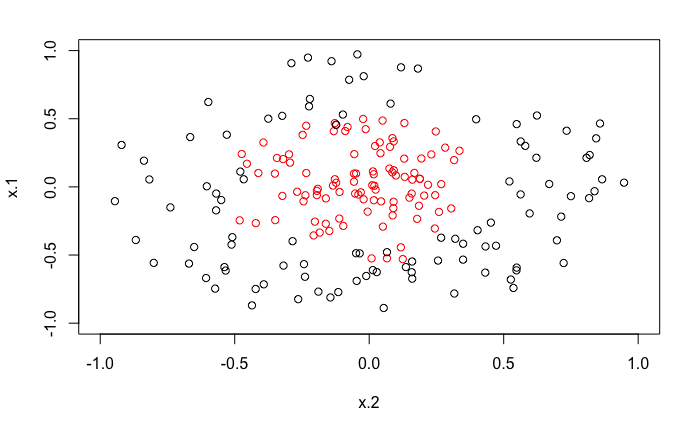

```r
set.seed(100)
insideR <- runif(100, max = 0.55)
insideA <- runif(100, max = 2*pi)
insideX <- insideR * cos(insideA)
insideY <- insideR * sin(insideA)
outsideR <- runif(100, min = 0.45, max = 1)
outsideA <- runif(100, max = 2*pi)
outsideX <- outsideR * cos(outsideA)
outsideY <- outsideR * sin(outsideA)
x <- matrix(c(insideX, outsideX, insideY, outsideY), ncol = 2, nrow = 200)
y <- c(rep(1, 100), rep(2,100))
simple.dat <- data.frame(x = x, y = as.factor(y))
plot(simple.dat[,c(2,1)], col = c("red", "black")[y], xlim = c(-1, 1), ylim = c(-1,1))
```

Линейное

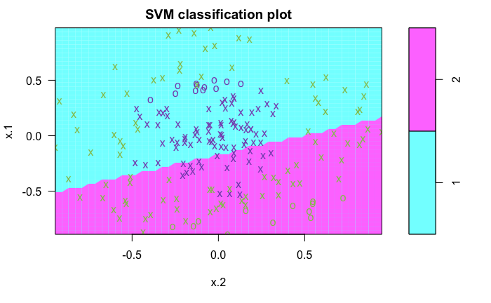

```r
set.seed(100)
tune.model.linear <- tune(svm, y ~ ., data = simple.dat, kernel = "linear", ranges = list(cost = c(0.001, 0.01, 0.1, 1, 5, 10, 50, 100)), scale = TRUE)
plot(tune.model.linear$best.model, simple.dat)
```

Тестовые данные:

```r
set.seed(100)
insideR.test <- runif(100, max = 0.55)
insideA.test <- runif(100, max = 2*pi)
insideX.test <- insideR.test * cos(insideA.test)
insideY.test <- insideR.test * sin(insideA.test)
outsideR.test <- runif(100, min = 0.45, max = 1)
outsideA.test <- runif(100, max = 2*pi)
outsideX.test <- outsideR.test * cos(outsideA.test)
outsideY.test <- outsideR.test * sin(outsideA.test)
```

Average accuracy

```r
x.test <- matrix(c(insideX.test, outsideX.test, insideY.test, outsideY.test), ncol = 2, nrow = 200)
y.test <- c(rep(1, 100), rep(2,100))
svm.model.pred <- predict(tune.model.linear$best.model, newdata = x.test)
tb <- table(svm.model.pred, y.test)
mean(diag(prop.table(tb, 1)))
```

```
[1] 0.6996637
```

RBF

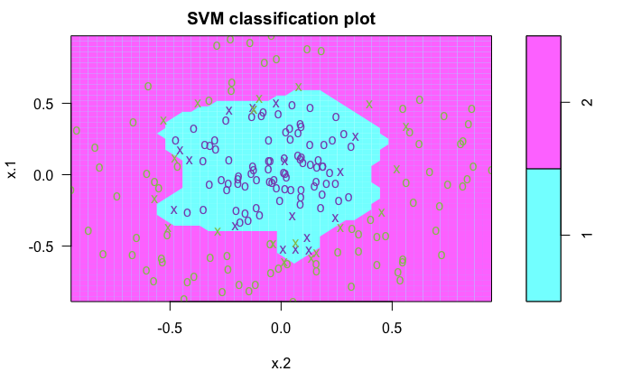

```r
set.seed(100)
tune.model.rbf <- tune(svm, y ~ ., data = simple.dat, kernel = "radial", ranges = list(cost = c(0.01, 0.1, 1, 5, 10, 50), gamma = c(0.1, 0.5, 1, 2, 3, 4)), scale = TRUE)
plot(tune.model.rbf$best.model, simple.dat)
```

Average accuracy

```r
svm.model.pred <- predict(tune.model.rbf$best.model, newdata = x.test)
tb <- table(svm.model.pred, y.test)
mean(diag(prop.table(tb, 1)))
```

```
[1] 0.9901961
```

# Multiclass SVM

Данные об экспрессии генов четырех типов опухолей.

- xtrain – тренировочная выборка (2308 признаков и 63 наблюдения)
- xtest – тестовая выборка (2308 признаков и 20 наблюдений)
- ytrain – 4 группы “EWS”, “BL-NHL”, “NB” и “RMS”
- ytest – 4 группы “EWS”, “BL-NHL”, “NB”, “RMS”

Воспользуемся функцией SVM из пакета gmum.r. Среди ее аргументов:

- x – матрица данных без ответов
- y – вектор с ответами (отметками классов)
- class.type – one vs. all или one vs. one
- C – trade-off между регуляризацией и строгостью классификации. Можно рассматривать как обратное к коэффициенту перед регулирующим слагаемым, подберем кроссвалидацией.
- kernel – ядро
- gamma, degree, coef0 – параметры ядер

## One-vs-one

```r
svm.gen.fit.ovo <- SVM(x = Khan$xtrain, y = as.factor(Khan$ytrain), class.type="one.versus.one", kernel = "linear", C = 0.001, verbosity=0)
svm.gen.ovo.pred <- predict(svm.gen.fit.ovo, Khan$xtest)
```

Confusion matrix:

```r
tb <- table(svm.gen.ovo.pred, as.factor(Khan$ytest))
print(tb)
```

```
svm.gen.ovo.pred 1 2 3 4
               1 3 0 0 0
               2 0 6 1 0
               3 0 0 5 0
               4 0 0 0 5
```

Average classification accuracy:

```r
mean(diag(prop.table(tb, 1)))
```

```
[1] 0.9642857
```

## One-vs-all

```r
svm.gen.fit.ova <- SVM(x = Khan$xtrain, y = as.factor(Khan$ytrain), class.type="one.versus.all", kernel = "linear", C = 0.001, verbosity=0)
svm.gen.ova.pred <- predict(svm.gen.fit.ova, Khan$xtest)
```

Confusion matrix:

```r
tb <- table(svm.gen.ova.pred, as.factor(Khan$ytest))
print(tb)
```

```
svm.gen.ova.pred 1 2 3 4
               1 3 0 0 0
               2 0 6 0 0
               3 0 0 6 0
               4 0 0 0 5
```

Average classification accuracy:

```r
mean(diag(prop.table(tb, 1)))
```

```
[1] 1
```

Оказалось, что One-vs-all подход дал лучший результат.

# Regularized SVM

В этом пункте вернемся к данным о продажах апельсинового сока.

Для построения регуляризованного SVM воспользуемся функцией Liblinear из одноименного пакета. Среди ее аргументов:

- data – матрица данных
- type – тип регуляризации. Поддерживаются L1 и L2 для L1 и L2 функций потерь
- target – вектор ответов
- cost – цена нарушения ограничений.
- cross – параметр k-fold cross-validation

## L1

```r
set.seed(100)
tryCosts <- c(0.001, 0.01, 0.1, 1, 5, 10, 50, 100, 1000)
bestCost <- NA
bestAcc <- 0

for(co in tryCosts){
  acc <- LiblineaR(data=scale(train.df[,-1]),target=as.factor(train.df$Purchase),type=5,cost=co,cross=10)
    cat("Results for C = ",co," : ",acc," accuracy.\n",sep="")
    if(acc>bestAcc){
      bestCost <- co
      bestAcc <- acc
    }
}
```

```
Results for C = 0.001 : 0.3871829 accuracy.
Results for C = 0.01 : 0.8331108 accuracy.
Results for C = 0.1 : 0.8251001 accuracy.
Results for C = 1 : 0.823765 accuracy.
Results for C = 5 : 0.8264352 accuracy.
Results for C = 10 : 0.8264352 accuracy.
Results for C = 50 : 0.8197597 accuracy.
Results for C = 100 : 0.8331108 accuracy.
Results for C = 1000 : 0.8251001 accuracy.
```

```r
cat("Best cost is:",bestCost,"\n")
```

```
Best cost is: 0.01
```

```r
cat("Best accuracy is:",bestAcc,"\n")
```

```
Best accuracy is: 0.8331108
```

Построим модель с подобранным параметром cost

```r
svm.l1.fit <- LiblineaR(data = scale(train.df[,-1]), type = 5, target = as.factor(train.df$Purchase), cost = bestCost)
```

Посмотрим на веса признаков

```r
svm.l1.fit$W
```

```
     WeekofPurchase PriceCH PriceMM   LoyalCH SalePriceCH PriceDiff ListPriceDiff      Bias
[1,]              0       0       0 0.5591594           0   0.14123   0.003624476 0.1624867
```

Регуляризация убрала 4 признака.

Проверим на тестовой выборке

```r
svm.l1.pred <- predict(svm.l1.fit, scale(test.df[,-1]))
```

Confusion matrix:

```r
tb <- table(svm.l1.pred$predictions, as.factor(test.df$Purchase))
print(tb)
```

```
      CH  MM
  CH 167  28
  MM  27  99
```

Average classification accuracy:

```r
mean(diag(prop.table(tb, 1)))
```

```
[1] 0.8210623
```

## L2

```r
set.seed(100)
tryCosts <- c(0.001, 0.01, 0.1, 1, 5, 10, 50, 100, 1000)
bestCost <- NA
bestAcc <- 0

for(co in tryCosts){
  acc <- LiblineaR(data=scale(train.df[,-1]),target=as.factor(train.df$Purchase),type=1,cost=co,cross=10)
    cat("Results for C = ",co," : ",acc," accuracy.\n",sep="")
    if(acc>bestAcc){
      bestCost <- co
      bestAcc <- acc
    }
}
```

```
Results for C = 0.001 : 0.8210948 accuracy.
Results for C = 0.01 : 0.8251001 accuracy.
Results for C = 0.1 : 0.8291055 accuracy.
Results for C = 1 : 0.8277704 accuracy.
Results for C = 5 : 0.8304406 accuracy.
Results for C = 10 : 0.8277704 accuracy.
Results for C = 50 : 0.811749 accuracy.
Results for C = 100 : 0.7957276 accuracy.
Results for C = 1000 : 0.7449933 accuracy.
```

```r
cat("Best cost is:",bestCost,"\n")
```

```
Best cost is: 5
```

```r
cat("Best accuracy is:",bestAcc,"\n")
```

```
Best accuracy is: 0.8304406
```

Построим модель с параметрами, выбранными скользящим контролем.

```r
svm.l2.fit <- LiblineaR(data = scale(train.df[,-1]), target = as.factor(train.df$Purchase),  type = 1, cost = bestCost)
```

Посмотрим на веса признаков

```r
svm.l2.fit$W
```

```
     WeekofPurchase    PriceCH    PriceMM   LoyalCH SalePriceCH PriceDiff ListPriceDiff      Bias
[1,]     0.01882606 0.01629811 0.03488627 0.6777513  -0.1032407 0.1976731     0.0291812 0.2806247
```

Ни один признак не обнулился.

Проверим на тестовой выборке.

```r
svm.l2.pred <- predict(svm.l2.fit, scale(test.df[,-1]))
```

Confusion matrix:

```r
tb <- table(svm.l2.pred$predictions, as.factor(test.df$Purchase))
print(tb)
```

```
      CH  MM
  CH 171  32
  MM  23  95
```

Average classification accuracy:

```r
mean(diag(prop.table(tb, 1)))
```

```
[1] 0.8237246
```

# Support Vector Regression

Прямая задача svr формулируется так:
$$\begin{align*}
\begin{cases}
\frac{1}{2}\mathbf{\beta}^\mathrm{T}\mathbf{\beta} + C\sum\limits_{i = 1}^n (\xi_i^{+} + \xi_i^{-}) \rightarrow \min\limits_\mathbf{\beta}\\
\xi_i^{+}, \xi_i^{-} \geq 0\\
y_i - \mathbf{\beta}^\mathrm{T}\mathbf{x}_i - \beta_0 \leq \varepsilon + \xi_i^{+}\\
-y_i + \mathbf{\beta}^\mathrm{T}\mathbf{x}_i + \beta_0 \leq \varepsilon + \xi_i^{-}
\end{cases}
\end{align*}$$
Двойственная к ней:
$$\begin{align*}
\begin{cases}
\frac{1}{2}(\mathbf{\alpha}^{-} - \mathbf{\alpha}^{+})^\mathrm{T}Q(\mathbf{\alpha}^{-} - \mathbf{\alpha}^{+}) + \varepsilon \sum\limits_{i = 1}^n (\alpha_i^{-} + \alpha_i^{+}) + \sum\limits_{i = 1}^n y_i(\alpha_i^{-} - \alpha_i^{+}) \rightarrow \min\limits_{\mathbf{\alpha}^{-}, \mathbf{\alpha}^{+}}\\
\mathbf{e}^\mathrm{T}(\mathbf{\alpha}^{-} - \mathbf{\alpha}^{+}) = 0\\
0 \leq \alpha_i^{-} - \alpha_i^{+} \leq C, i = 1, \ldots, n
\end{cases}
\end{align*}$$
Ее решение:
$$\begin{align*}
y(\mathbf{x}) = \sum\limits_{i = 1}^n (-\alpha_i^{-} + \alpha_i^{+})K(\mathbf{x}_i, \mathbf{x}) + \beta_0
\end{align*}$$

Строить SVR можно снова с помощью функции svm из пакета e1071.

Для примера рассмотрим данные, с которыми мы уже работали на первом семинаре.

Hitters – Major League Baseball Data from the 1986 and 1987 seasons.

- AtBat – Number of times at bat in 1986
- Hits – Number of hits in 1986
- HmRun – Number of home runs in 1986
- Runs – Number of runs in 1986
- RBI – Number of runs batted in in 1986
- Walks – Number of walks in 1986
- Years – Number of years in the major leagues
- CAtBat – Number of times at bat during his career
- CHits – Number of hits during his career
- CHmRun – Number of home runs during his career
- CRuns – Number of runs during his career
- CRBI – Number of runs batted in during his career
- CWalks – Number of walks during his career
- League – A factor with levels A and N indicating player’s league at the end of 1986
- Division – A factor with levels E and W indicating player’s division at the end of 1986
- PutOuts – Number of put outs in 1986
- Assists – Number of assists in 1986
- Errors – Number of errors in 1986
- Salary – 1987 annual salary on opening day in thousands of dollars
- NewLeague – A factor with levels A and N indicating player’s league at the beginning of 1987

Делаем все признаки numeric и убираем NA.

```r
hit <- na.omit(Hitters)
x <- model.matrix(Salary~.,hit)[,-1]
y <- hit$Salary
```

Делим на тренировочную и тестовую выборки.

```r
set.seed(100)
train <- sample(1: nrow(x), nrow(x)/2)
test <- - train
x.train <- x[train,]
x.test <- x[test,]
y.train <- x[train]
y.test <- y[test]
```

Посмотрим на результат лучшей из рассматривавшихся моделей.

```r
set.seed(100)
cv.out <- cv.glmnet(x.train,y.train,alpha =0)
bestlam <- cv.out$lambda.min
ridge.mod <- glmnet(x.train,y.train, alpha=0, lambda=bestlam, standardize=TRUE)
ridge.pred <- predict(ridge.mod, s=bestlam, newx=x.test)
mean(sqrt((ridge.pred - y.test)^2))
```

```
[1] 281.9133
```

Теперь построим SVR.

```r
tune.linear.svr <- tune(svm, train.x = x.train, train.y = y.train, kernel = "linear", ranges = list(cost = c(0.001, 0.01, 0.1, 1, 5, 10, 50, 100)))
summary(tune.linear.svr)
```

```
Parameter tuning of ‘svm’:

- sampling method: 10-fold cross validation

- best parameters:
 cost
    1

- best performance: 124.8134

- Detailed performance results:
   cost     error dispersion
1 1e-03 8406.2740 2796.52639
2 1e-02  772.8485  362.47258
3 1e-01  152.1851   73.23473
4 1e+00  124.8134   79.91942
5 5e+00  124.8134   79.91942
6 1e+01  124.8134   79.91942
7 5e+01  124.8134   79.91942
8 1e+02  124.8134   79.91942
```

```r
tune.linear.svr$best.model
```

```
Call:
best.tune(method = svm, train.x = x.train, train.y = y.train, ranges = list(cost = c(0.001, 0.01, 0.1, 1, 5, 10, 50, 100)), kernel = "linear")


Parameters:
   SVM-Type:  eps-regression
 SVM-Kernel:  linear
       cost:  1
      gamma:  0.05263158
    epsilon:  0.1


Number of Support Vectors:  15
```

```r
svr.linear.pred <- predict(tune.linear.svr$best.model, x.test)
mean(sqrt((svr.linear.pred - y.test)^2))
```

```
[1] 280.7018
```

Получилось чуть лучше ridge regression.